# h3sdm workflow for a single model

## Introduction

This vignette demonstrates a complete workflow for species distribution modeling (SDM) for a single species using `h3sdm`. We cover data preparation, model fitting, spatial cross-validation, prediction, and feature importance.

## Load packages

```r
library(h3sdm)
library(sf)
library(terra)
library(dplyr)
library(ggplot2)
library(tidymodels)
library(spatialsample)
library(DALEX)
library(themis)
```

## 1. Define the Area of Interest

```r
cr <- cr_outline_c
```

## 2. Load Environmental Predictors

```r
bio <- terra::rast(system.file("extdata", "bioclim_current.tif", package = "h3sdm"))
names(bio) <- gsub(".*bio_", "bio", names(bio))
```

## 3. Create the Hexagonal Grid

The hexagonal grid is the backbone of the `h3sdm` workflow. All subsequent steps — predictor extraction, presence assignment, and pseudo-absence generation — are built on top of it. The resolution controls the spatial scale of the analysis. At resolution 7, each hexagon covers approximately 514 ha, which is appropriate for many vertebrate species.

```r
h7 <- h3sdm_get_grid(cr, res = 7)
```

## 4. Prepare Predictors

Environmental variables are extracted for every hexagon in the grid. Here we use three WorldClim bioclimatic variables: Bio1 (Annual Mean Temperature), Bio12 (Annual Precipitation), and Bio15 (Precipitation Seasonality).

```r
bio_predictors <- h3sdm_extract_num(bio, h7)
```

```
#>   |                                                                              |                                                                      |   0%  |                                                                              |                                                         …
```

```r
predictors <- h3sdm_predictors(bio_predictors) |>
  dplyr::select(h3_address, bio1, bio12, bio15, geometry)
```

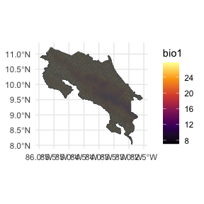

```r
ggplot() +
  theme_minimal() +
  geom_sf(data = predictors, aes(fill = bio1)) +
  scale_fill_viridis_c(option = "B")
```

## 5. Species Occurrence Data

Presence hexagons are generated using `h3sdm_pres()`, which downloads occurrence records and assigns them to hexagons. Multiple records within the same hexagon are consolidated into a single presence, reducing spatial sampling bias. Since each hexagon represents an area (~514 ha at resolution 7), this better reflects how organisms actually occupy space.

```r
pres <- h3sdm_pres("Silverstoneia flotator", cr, res = 7, limit = 10000)
```

```r
records <- h3sdm_pa(pres, predictors, n_pseudoabs = 300)
```

```r
table(records$presence)
```

```
#>
#>   0   1
#> 300 130
```

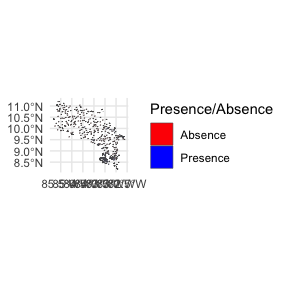

```r
ggplot() +
  theme_minimal() +
  geom_sf(data = records, aes(fill = presence)) +
  scale_fill_manual(
    name = "Presence/Absence",
    values = c("red", "blue"),
    labels = c("Absence", "Presence")
  )
```

## 6. Combine Records and Predictors

```r
dat <- h3sdm_data(records, predictors)
```

## 7. Spatial Cross-Validation

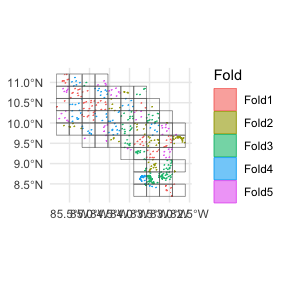

```r
scv <- h3sdm_spatial_cv(dat, v = 5, repeats = 1)
autoplot(scv) + theme_minimal()
```

## 8. Define Recipe and Model

```r
receta <- h3sdm_recipe(dat) |>
  themis::step_downsample(presence)

modelo <- parsnip::logistic_reg() |>
  parsnip::set_engine("glm") |>
  parsnip::set_mode("classification")
```

## 9. Create Workflow

```r
wf <- h3sdm_workflow(modelo, receta)
```

## 10. Fit the Model

```r
presence_data <- dat |>
  dplyr::filter(presence == 1)

f <- h3sdm_fit_model(wf, scv, presence_data)
```

## 11. Evaluate Model Performance

```r
evaluation_metrics <- h3sdm_eval_metrics(
  fitted_model  = f$cv_model,
  presence_data = presence_data
)
evaluation_metrics
```

```
#> # A tibble: 8 × 6
#>   .metric  .estimator  mean std_err conf_low conf_high
#>   <chr>    <chr>      <dbl>   <dbl>    <dbl>     <dbl>
#> 1 accuracy binary     0.693  0.0260    0.642     0.744
#> 2 f_meas   binary     0.748  0.0522    0.646     0.851
#> 3 kap      binary     0.282  0.0601    0.164     0.400
#> 4 roc_auc  binary     0.752  0.0370    0.679     0.824
#> 5 sens     binary     0.669  0.0302    0.609     0.728
#> 6 spec     binary     0.767  0.0952    0.581     0.954
#> 7 tss      binary     0.49  NA        NA        NA
#> 8 boyce    binary     0.568 NA        NA        NA
```

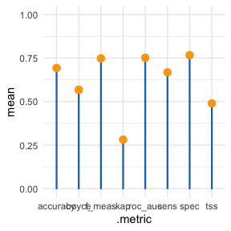

```r
ggplot(evaluation_metrics, aes(.metric, mean)) +
  theme_minimal() +
  geom_col(width = 0.03, color = "dodgerblue3", fill = "dodgerblue3") +
  geom_point(size = 3, color = "orange") +
  ylim(0, 1)
```

## 12. Make Predictions

```r
p <- h3sdm_predict(f, predictors)
```

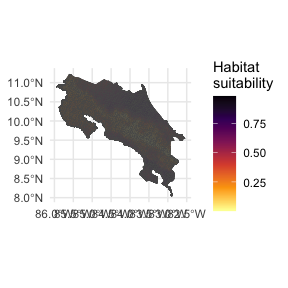

```r
ggplot() +
  theme_minimal() +
  geom_sf(data = p, aes(fill = prediction)) +
  scale_fill_viridis_c(name = "Habitat\nsuitability", option = "B", direction = -1)
```

## 13. Model Interpretation

```r
e <- h3sdm_explain(f$final_model, data = dat)
```

```
#> Preparation of a new explainer is initiated
#>   -> model label       :  h3sdm workflow
#>   -> data              :  430  rows  6  cols
#>   -> target variable   :  430  values
#>   -> predict function  :  custom_predict
#>   -> predicted values  :  No value for predict function target column. (  default  )
#>   -> model_info        :  package Model of class: workflow package unrecognized , ver. Unknown , task regression (  default  )
#>   -> predicted values  :  numerical, min =  0.003968531 , mean =  0.4467184 , max =  0.9749553
#>   -> residual function :  difference between y and yhat (  default  )
#>   -> residuals         :  numerical, min =  -0.9749553 , mean =  -0.1443928 , max =  0.8506566
#>   A new explainer has been created!
```

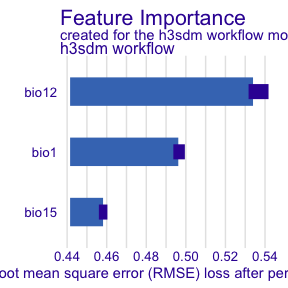

```r
predictors_to_evaluate <- setdiff(names(e$data), c("h3_address", "x", "y", "presence"))

var_imp <- DALEX::model_parts(
  explainer = e,
  variables = predictors_to_evaluate
)
plot(var_imp)
```

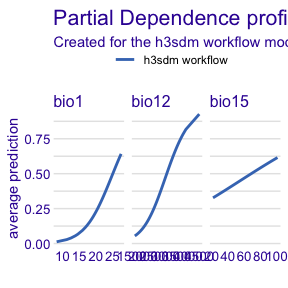

```r
pdp_glm <- ingredients::partial_dependence(e, variables = c("bio12", "bio1", "bio15"))
plot(pdp_glm)
```

## 14. Future Scenario Predictions

```r
bio_future <- terra::rast(system.file("extdata", "bioclim_future.tif", package = "h3sdm"))
names(bio_future) <- c("bio1", "bio12", "bio15")

bio_future_predictors <- h3sdm_extract_num(bio_future, h7)
```

```
#>   |                                                                              |                                                                      |   0%  |                                                                              |                                                         …
```

```r
predictors_future <- h3sdm_predictors(bio_future_predictors)

p_future <- h3sdm_predict(f, predictors_future)
```

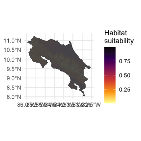

```r
ggplot() +
  theme_minimal() +
  geom_sf(data = p_future, aes(fill = prediction)) +
  scale_fill_viridis_c(name = "Habitat\nsuitability", option = "B", direction = -1)
```

## Conclusions

This vignette demonstrated a complete SDM workflow using `h3sdm`, including data preparation with a hexagonal grid, presence assignment, environmentally stratified pseudo-absence generation, model fitting with spatial cross-validation, performance evaluation, predictions, and variable importance analysis for both current and future climate scenarios.